# Housing & Schools Analysis

### Analysis

*Include at least one regression result*

Now that we know more about the dataset and these trends, let’s move on to the regression.

For this, I wanted to perform a multiple linear regression to predict the sold price of houses based on various predictors. Indeed, I wanted to know what factors really influence the sale price.

Here is my model:

```r
# Fit the multiple linear regression model
lm_model <- lm(soldprice ~ sqft + beds + baths + year + neighborhood + elementary_rating + middle_rating + high_rating, data = housingMerg)

# Summary of the model
summary(lm_model)
```

```
##
## Call:
## lm(formula = soldprice ~ sqft + beds + baths + year + neighborhood +
##     elementary_rating + middle_rating + high_rating, data = housingMerg)
##
## Residuals:
##     Min      1Q  Median      3Q     Max
## -547281 -283744  109267  236556  559883
##
## Coefficients:
##                      Estimate Std. Error t value Pr(>|t|)
## (Intercept)        -6.240e+06  1.160e+06  -5.377 1.05e-07 ***
## sqft                1.560e+01  2.854e+01   0.547   0.5849
## beds                5.853e+04  2.026e+04   2.888   0.0040 **
## baths               2.504e+04  1.804e+04   1.388   0.1657
## year                3.353e+03  5.821e+02   5.760 1.28e-08 ***
## neighborhoodGold    7.907e+03  6.375e+04   0.124   0.9013
## neighborhoodGreen   1.566e+04  4.140e+04   0.378   0.7054
## neighborhoodOrange  4.504e+04  3.757e+04   1.199   0.2310
## neighborhoodPurple -9.806e+04  1.658e+05  -0.592   0.5543
## neighborhoodRed     1.254e+05  6.437e+04   1.948   0.0518 .
## neighborhoodSilver  3.057e+04  4.446e+04   0.688   0.4919
## neighborhoodYellow -4.132e+04  5.143e+04  -0.803   0.4221
## elementary_rating   3.375e+03  6.518e+03   0.518   0.6048
## middle_rating       3.319e+04  1.158e+04   2.865   0.0043 **
## high_rating         5.243e+04  6.069e+03   8.639  < 2e-16 ***
## ---
## Signif. codes:  0 '***' 0.001 '**' 0.01 '*' 0.05 '.' 0.1 ' ' 1
##
## Residual standard error: 280100 on 668 degrees of freedom
## Multiple R-squared:  0.4499, Adjusted R-squared:  0.4384
## F-statistic: 39.03 on 14 and 668 DF,  p-value: < 2.2e-16
```

The model predicts the soldprice based on sqft, beds, baths, year, neighborhood, and rating. The summary(lm_model) provides coefficients, standard errors, t-values, and p-values for each predictor, along with R-squared and adjusted R-squared values to assess the model’s fit.

Here are the results:

Therefore, the analysis of the model indicates that while certain variables like the number of bedrooms, the year the house was built, and school ratings (middle and high school) have significant effects on the sold price, others such as square footage and the specific neighborhood do not, after accounting for other factors in the model.

This is quite a surprising result. Indeed, the surface area is generally a means of determining the price of housing and is commonly used to compare the price of housing depending on the location, and therefore the neighborhood.

Let’s plot the residuals to check the fit of this model :

The residual plot helps to visually check if the residuals are randomly distributed, indicating a good model fit.

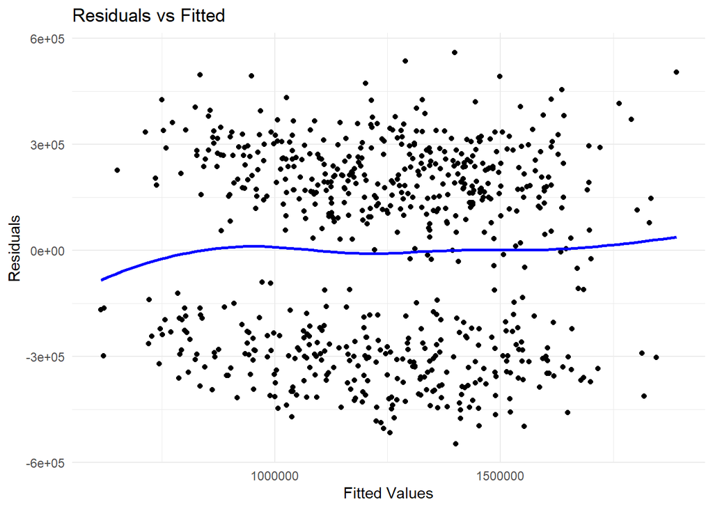

```r
# Plotting the residuals to check the fit
ggplot(lm_model, aes(.fitted, .resid)) +
  geom_point() +
  geom_smooth(method = "loess", se = FALSE, col = "blue") +
  labs(title = "Residuals vs Fitted", x = "Fitted Values", y = "Residuals") +
  theme_minimal()
```

We observe 2 groups of points, one above 0, the other below 0, almost in symmetry. The blue line crosses the graph and generally runs along the x axis at y = 0, thus passing between the 2 groups of points.

Here is what we can say about the graph:

- This symmetry suggests that the model does not systematically overpredict or underpredict the sold prices across the range of fitted values: the model’s predictions are, on average, correct.
- Ideally, residuals should be randomly scattered around the horizontal axis without any distinct patterns or groups. The fact that we can see 2 groups of point may suggest that the model fits certain ranges of the data better than others.
- The fact that the line crosses the graph and runs close to the x-axis suggests that there is no major systematic error in the model: on average, the residuals are centered around zero and the model’s predictions are not biased.

**Therefore, while the model appears to be unbiased on average, the distinct grouping of residuals suggests there might be underlying complexities that need to be addressed to improve the model’s fit.**

*Include at least one clustering result*

We will use k-means clustering to group the houses based on sqft, beds, baths, and soldprice.

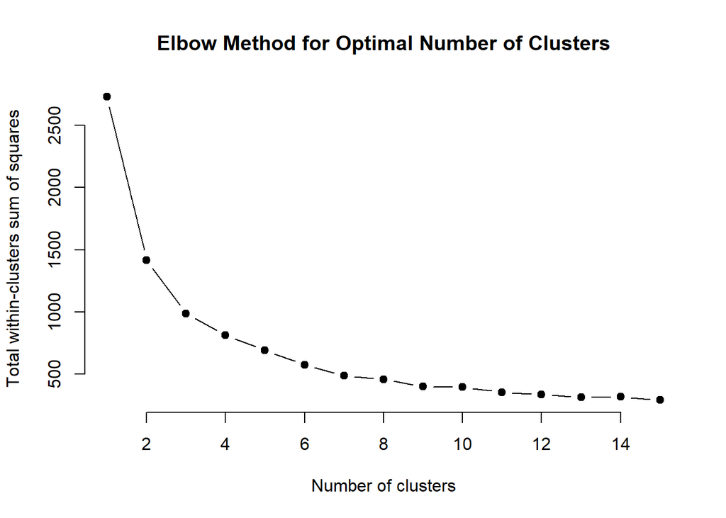

```r
# Prepare the data for clustering
cluster_data <- housingMerg %>%
  select(sqft, beds, baths, soldprice) %>%
  na.omit()

# Standardize the data
cluster_data_scaled <- scale(cluster_data)

# Determine the optimal number of clusters using the elbow method
wss <- (nrow(cluster_data_scaled)-1)*sum(apply(cluster_data_scaled, 2, var))
for (i in 2:15) wss[i] <- sum(kmeans(cluster_data_scaled, centers=i)$tot.withinss)

# Plot the elbow method
plot(1:15, wss, type="b", pch = 19, frame = FALSE,
     xlab="Number of clusters", ylab="Total within-clusters sum of squares",
     main = "Elbow Method for Optimal Number of Clusters")
```

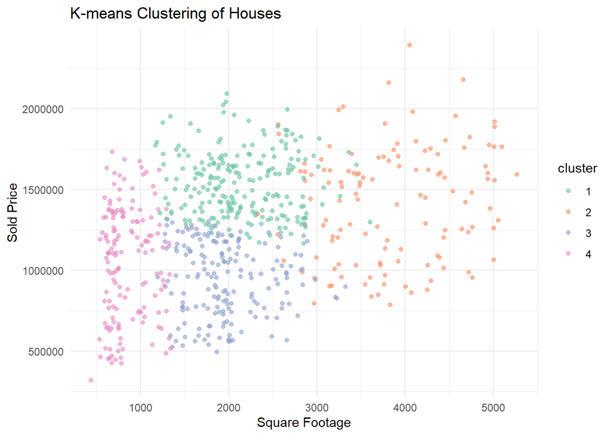

```r
# Perform k-means clustering with the chosen number of clusters
set.seed(123)
kmeans_model <- kmeans(cluster_data_scaled, centers = 4)  # Assuming 4 clusters based on elbow method

# Add cluster assignment to the original data
housingMerg$cluster <- factor(kmeans_model$cluster)

# Plot the clusters
ggplot(housingMerg, aes(x = sqft, y = soldprice, color = cluster)) +
  geom_point(alpha = 0.6) +
  labs(title = "K-means Clustering of Houses", x = "Square Footage", y = "Sold Price") +
  theme_minimal() +
  scale_color_brewer(palette = "Set2")
```

The cluster_data contains selected features (sqft, beds, baths, soldprice) for clustering. The data is standardized using scale to ensure all features contribute equally to the distance calculations. The elbow method helps determine the optimal number of clusters by plotting the total within-clusters sum of squares against the number of clusters. K-means clustering is performed with the chosen number of clusters, and cluster assignments are added to the original data.

### Sensitive Analysis

Let’s remove all oddities and outliers from the dataset.

```r
housing <-read.csv("housing.csv", header = T)
dim(housing)
```

```
## [1] 683  15
```

```r
# Categorization
housing$neighborhood <- as.factor(housing$neighborhood)
housing$type <- as.factor(housing$type)
housing$levels <- as.integer(housing$levels)
housing$cooling <- as.factor(housing$cooling)
housing$heating <- as.factor(housing$heating)
housing$fireplace <- as.factor(housing$fireplace)
housing$elementary <- as.factor(housing$elementary)
housing$middle <- as.factor(housing$middle)
housing$high <- as.factor(housing$high)

# Combine duplicates
housing$type[housing$type == "condominium"] <- "condo"
housing$type[housing$type == "town house"] <- "townhouse"
housing$type <- as.factor(housing$type)


# Remove outliers
housing <- subset(housing, beds != 999)
housing <- subset(housing, baths != 25)
housing <- subset(housing, year != 1495)
housing <- subset(housing, year != 2111)
housing <- subset(housing, soldprice != 664)


# Trim leading and trailing spaces in the cooling, heating and fireplace column
housing$cooling <- str_trim(housing$cooling)
housing$heating <- str_trim(housing$heating)
housing$fireplace <- str_trim(housing$fireplace)

# Replace empty strings with NA
housing$cooling[housing$cooling == ""] <- NA
housing$heating[housing$heating == ""] <- NA
housing$fireplace[housing$fireplace == ""] <- NA

# Replace Yes by 1 and No by 0
housing$cooling <- ifelse(housing$cooling == "Yes", 1,
                                      ifelse(housing$cooling == "No", 0, NA))
housing$heating <- ifelse(housing$heating == "Yes", 1,
                                      ifelse(housing$heating == "No", 0, NA))
housing$fireplace <- ifelse(housing$fireplace == "Yes", 1,
                                          ifelse(housing$fireplace == "No", 0, NA))

# Remove NA's
housing_clean <- na.omit(housing)

summary(housing_clean)
```

```
##   neighborhood      beds           baths           sqft         lotsize
##  Orange :133   Min.   :1.000   Min.   :1.00   Min.   : 536   Min.   :0.0700
##  Blue   :126   1st Qu.:3.000   1st Qu.:1.00   1st Qu.:1381   1st Qu.:0.1600
##  Red    :109   Median :4.000   Median :1.50   Median :1961   Median :0.2400
##  Green  : 91   Mean   :3.502   Mean   :1.99   Mean   :2135   Mean   :0.2899
##  Yellow : 64   3rd Qu.:4.000   3rd Qu.:2.50   3rd Qu.:2680   3rd Qu.:0.3600
##  Silver : 62   Max.   :6.000   Max.   :5.00   Max.   :5097   Max.   :1.3000
##  (Other): 50
##       year                      type         levels         cooling
##  Min.   :1908   condo             :140   Min.   :1.000   Min.   :0.0000
##  1st Qu.:1960   condominium       :  0   1st Qu.:1.000   1st Qu.:0.0000
##  Median :1978   multi-family home : 62   Median :1.000   Median :0.0000
##  Mean   :1978   single-family home:313   Mean   :1.373   Mean   :0.3339
##  3rd Qu.:1997   town house        :  0   3rd Qu.:2.000   3rd Qu.:1.0000
##  Max.   :2018   townhouse         :120   Max.   :2.000   Max.   :1.0000
##
##     heating         fireplace                    elementary
##  Min.   :0.0000   Min.   :0.0000   Leopard Elementary : 47
##  1st Qu.:0.0000   1st Qu.:0.0000   Savannah Elementary: 35
##  Median :0.0000   Median :0.0000   Kodkod Elementary  : 34
##  Mean   :0.2126   Mean   :0.3244   Puma Elementary    : 34
##  3rd Qu.:0.0000   3rd Qu.:1.0000   Bobcat Elementary  : 33
##  Max.   :1.0000   Max.   :1.0000   Cheetah Elementary : 32
##                                    (Other)            :420
##             middle                high       soldprice
##  Wolf Middle   : 59   Channel High  : 64   Min.   : 423000
##  Fox Middle    : 52   Delta High    : 62   1st Qu.: 973000
##  Hound Middle  : 51   Crevasse High : 56   Median :1267000
##  Coyote Middle : 50   Alpine High   : 53   Mean   :1248572
##  Sloth Middle  : 47   Summit High   : 48   3rd Qu.:1553000
##  Raccoon Middle: 45   Avalanche High: 47   Max.   :2393000
##  (Other)       :331   (Other)       :305
```

```r
dim(housing_clean)
```

```
## [1] 635  15
```

With this method, we go from 683 row to 635, which means we removed 48 rows from housing.csv.

```r
schoolsData <-read.csv("schools.csv", header = T)
dim(schoolsData)
```

```
## [1] 52  3
```

We know from above that schools.csv does not contain any oddities or outliers. We procede to the merge:

```r
# Create new dataset
housingMergNew <- housing_clean

# Merge the housing and schools datasets based on the elementary school
housingMergNew <- housingMergNew %>%
  left_join(schoolsData %>% rename(elementary_rating = rating, elementary_size = size),
            by = c("elementary" = "school"))

# Merge the housing and schools datasets based on the middle school
housingMergNew <- housingMergNew %>%
  left_join(schoolsData %>% rename(middle_rating = rating, middle_size = size),
            by = c("middle" = "school"))

# Merge the housing and schools datasets based on the high school
housingMergNew <- housingMergNew %>%
  left_join(schoolsData %>% rename(high_rating = rating, high_size = size),
            by = c("high" = "school"))

# Verify the merge
summary(housingMergNew)
```

```
##   neighborhood      beds           baths           sqft         lotsize
##  Orange :133   Min.   :1.000   Min.   :1.00   Min.   : 536   Min.   :0.0700
##  Blue   :126   1st Qu.:3.000   1st Qu.:1.00   1st Qu.:1381   1st Qu.:0.1600
##  Red    :109   Median :4.000   Median :1.50   Median :1961   Median :0.2400
##  Green  : 91   Mean   :3.502   Mean   :1.99   Mean   :2135   Mean   :0.2899
##  Yellow : 64   3rd Qu.:4.000   3rd Qu.:2.50   3rd Qu.:2680   3rd Qu.:0.3600
##  Silver : 62   Max.   :6.000   Max.   :5.00   Max.   :5097   Max.   :1.3000
##  (Other): 50
##       year                      type         levels         cooling
##  Min.   :1908   condo             :140   Min.   :1.000   Min.   :0.0000
##  1st Qu.:1960   condominium       :  0   1st Qu.:1.000   1st Qu.:0.0000
##  Median :1978   multi-family home : 62   Median :1.000   Median :0.0000
##  Mean   :1978   single-family home:313   Mean   :1.373   Mean   :0.3339
##  3rd Qu.:1997   town house        :  0   3rd Qu.:2.000   3rd Qu.:1.0000
##  Max.   :2018   townhouse         :120   Max.   :2.000   Max.   :1.0000
##
##     heating         fireplace       elementary           middle
##  Min.   :0.0000   Min.   :0.0000   Length:635         Length:635
##  1st Qu.:0.0000   1st Qu.:0.0000   Class :character   Class :character
##  Median :0.0000   Median :0.0000   Mode  :character   Mode  :character
##  Mean   :0.2126   Mean   :0.3244
##  3rd Qu.:0.0000   3rd Qu.:1.0000
##  Max.   :1.0000   Max.   :1.0000
##
##      high             soldprice       elementary_size elementary_rating
##  Length:635         Min.   : 423000   Min.   :600.0   Min.   : 1.000
##  Class :character   1st Qu.: 973000   1st Qu.:700.0   1st Qu.: 4.000
##  Mode  :character   Median :1267000   Median :750.0   Median : 6.000
##                     Mean   :1248572   Mean   :744.6   Mean   : 5.751
##                     3rd Qu.:1553000   3rd Qu.:800.0   3rd Qu.: 8.000
##                     Max.   :2393000   Max.   :900.0   Max.   :10.000
##
##   middle_size    middle_rating     high_size       high_rating
##  Min.   :500.0   Min.   :2.000   Min.   : 750.0   Min.   : 1.000
##  1st Qu.:600.0   1st Qu.:5.000   1st Qu.: 850.0   1st Qu.: 4.000
##  Median :700.0   Median :7.000   Median :1000.0   Median : 6.000
##  Mean   :694.2   Mean   :6.161   Mean   : 964.3   Mean   : 5.918
##  3rd Qu.:800.0   3rd Qu.:7.500   3rd Qu.:1100.0   3rd Qu.: 8.000
##  Max.   :900.0   Max.   :9.000   Max.   :1250.0   Max.   :10.000
##
```

Some values of the summary statistics changes. This is particularly the case for the square feet column for which all the values are different.

**Analysis part**

Let’s compare the model results:

```r
# Fit the multiple linear regression model
lm_model <- lm(soldprice ~ sqft + beds + baths + year + neighborhood + elementary_rating + middle_rating + high_rating, data = housingMergNew)

# Summary of the model
summary(lm_model)
```

```
##
## Call:
## lm(formula = soldprice ~ sqft + beds + baths + year + neighborhood +
##     elementary_rating + middle_rating + high_rating, data = housingMergNew)
##
## Residuals:
##     Min      1Q  Median      3Q     Max
## -556889 -289617  107268  240090  543227
##
## Coefficients:
##                      Estimate Std. Error t value Pr(>|t|)
## (Intercept)        -6.045e+06  1.209e+06  -5.002 7.42e-07 ***
## sqft                7.014e+00  3.007e+01   0.233  0.81563
## beds                5.816e+04  2.138e+04   2.720  0.00671 **
## baths               3.292e+04  1.895e+04   1.737  0.08282 .
## year                3.280e+03  6.064e+02   5.409 9.05e-08 ***
## neighborhoodGold    3.764e+04  6.694e+04   0.562  0.57411
## neighborhoodGreen   2.084e+04  4.375e+04   0.476  0.63397
## neighborhoodOrange  3.541e+04  3.908e+04   0.906  0.36530
## neighborhoodPurple -1.164e+05  1.675e+05  -0.695  0.48734
## neighborhoodRed     9.462e+04  6.740e+04   1.404  0.16085
## neighborhoodSilver  2.525e+04  4.648e+04   0.543  0.58717
## neighborhoodYellow -3.270e+04  5.349e+04  -0.611  0.54121
## elementary_rating   1.853e+02  6.795e+03   0.027  0.97825
## middle_rating       3.159e+04  1.207e+04   2.617  0.00910 **
## high_rating         5.057e+04  6.327e+03   7.993 6.48e-15 ***
## ---
## Signif. codes:  0 '***' 0.001 '**' 0.01 '*' 0.05 '.' 0.1 ' ' 1
##
## Residual standard error: 282600 on 620 degrees of freedom
## Multiple R-squared:  0.4447, Adjusted R-squared:  0.4322
## F-statistic: 35.47 on 14 and 620 DF,  p-value: < 2.2e-16
```

Also by comparing the graphs, we do not see any major difference:

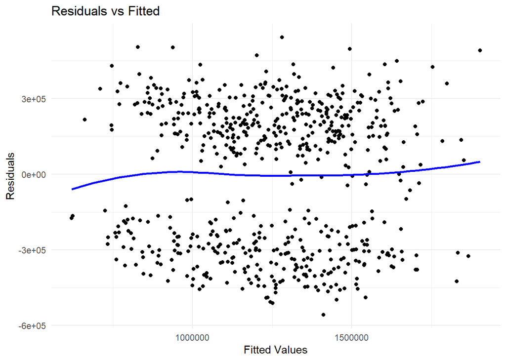

```r
# Plotting the residuals to check the fit
ggplot(lm_model, aes(.fitted, .resid)) +
  geom_point() +
  geom_smooth(method = "loess", se = FALSE, col = "blue") +
  labs(title = "Residuals vs Fitted", x = "Fitted Values", y = "Residuals") +
  theme_minimal()
```

We get the exact same description as earlier.

Finally, K-means gives exactly the same observations:

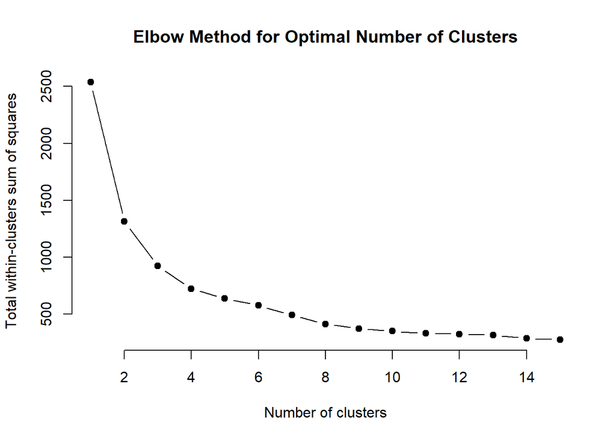

```r
# Prepare the data for clustering
cluster_data <- housingMergNew %>%
  select(sqft, beds, baths, soldprice) %>%
  na.omit()

# Standardize the data
cluster_data_scaled <- scale(cluster_data)

# Determine the optimal number of clusters using the elbow method
wss <- (nrow(cluster_data_scaled)-1)*sum(apply(cluster_data_scaled, 2, var))
for (i in 2:15) wss[i] <- sum(kmeans(cluster_data_scaled, centers=i)$tot.withinss)

# Plot the elbow method
plot(1:15, wss, type="b", pch = 19, frame = FALSE,
     xlab="Number of clusters", ylab="Total within-clusters sum of squares",
     main = "Elbow Method for Optimal Number of Clusters")
```

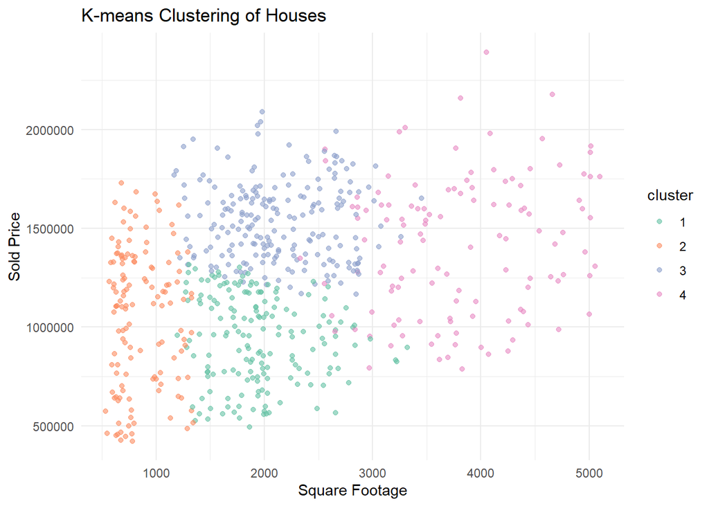

```r
# Perform k-means clustering with the chosen number of clusters
set.seed(123)
kmeans_model <- kmeans(cluster_data_scaled, centers = 4)  # Assuming 4 clusters based on elbow method

# Add cluster assignment to the original data
housingMergNew$cluster <- factor(kmeans_model$cluster)

# Plot the clusters
ggplot(housingMergNew, aes(x = sqft, y = soldprice, color = cluster)) +
  geom_point(alpha = 0.6) +
  labs(title = "K-means Clustering of Houses", x = "Square Footage", y = "Sold Price") +
  theme_minimal() +
  scale_color_brewer(palette = "Set2")
```

It seems that, in this dataset, the loss of 48 rows does not affect the analysis results.

The similarity in results between deleting anomalies and readjusting values with predictions can be attributed to the inherent robustness of the dataset, the accuracy of prediction models, and the nature of the anomalies. Both methods aim to improve data quality, and when done correctly, they can lead to datasets that faithfully represent the underlying trends and patterns, resulting in similar analytical outcomes.